# Silicon Sampling and Decision Models

Lecture 13b  
POLS 6394 · Week 13 · Thursday, November 19

## Today

- Agents that keep running: terminal multiplexers and Herdr
- Why silicon sampling, and its limits
- One persona and a structured answer
- Validate archived predictions against people
- Lab
- Your paper, then Problem Set 7
- If time remains: decision models and probabilities

Stay on slides through *Your agents, from your phone*

# Picking up

## Where we left off

Yesterday ended at *Check what it did*: your `divides` report is committed and pushed. Today: Herdr, then 13b, then your paper.

Reopen Codex in the sandbox, where yesterday’s conversation is:

```bash
course
z sandbox
codex resume --last
```

Type `/status`: the folder should end in `Labs/w12/sandbox`. Then ask Codex to pull, which brings in today’s `13b-workbook.qmd`:

```
Pull the latest from GitHub and tell me what came in.
```

Never got to *Keep the work*? Do that section of the 13a workbook first.

Then stay on slides through *Your agents, from your phone*

# Coming back later

## Coming back to a conversation

`/exit` closes Codex, and the conversation is saved.

- `codex resume --last` reopens the last one in this folder.
- `codex resume` lists them all; pick one with the arrow keys.

Conversations belong to the folder you started them in. Files don’t depend on the conversation: whatever Codex changed is already on disk.

Stay on slides through *Your agents, from your phone*

## When a conversation gets long

Everything in a conversation takes up room in the model’s working memory, its **context**.

When that fills, Codex **compacts**: it summarizes the older parts and keeps going. Most of the time you won’t notice.

If it seems to have lost a detail, say it again. Anything that must never be lost belongs in a file, like `AGENTS.md` or `NOTES.md`.

Stay on slides through *Your agents, from your phone*

## When the laptop sleeps, Codex stops

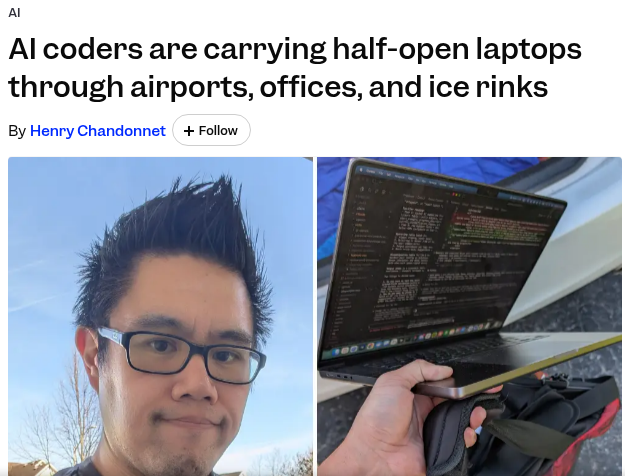

Codex runs on your computer. When it sleeps or shuts down, Codex stops.

For jobs of seconds or minutes, that doesn’t matter.

For longer ones, keep the laptop awake and plugged in, or run the agent on a computer that stays on.

After sleep, check what finished before asking Codex to continue.

Henry Chandonnet, [“AI coders are carrying half-open laptops through airports, offices, and ice rinks,”](https://www.businessinsider.com/coders-keep-laptops-open-in-public-ai-agent-2026-5) *Business Insider*, May 12, 2026.

Stay on slides through *Your agents, from your phone*

## Switching computers

Your files travel with Git: push on one computer, pull on the other.

Conversations stay on the computer where they happened. On another machine, Codex starts with no memory of the work.

So **start and finish a task on one computer**, and keep what matters (plans, checks, decisions) in files like `NOTES.md` and `PAPER.md`. Those travel with Git.

Stay on slides through *Your agents, from your phone*

# Agents that keep running

## One window, one agent

So far Codex has lived in one terminal window on your laptop.

- Close the window, and Codex stops.
- Close the laptop lid, and Codex stops.
- Want a second agent? Open a second window, and keep track of which is which.

For a two-minute job, none of that matters. For a job that runs an hour, or two agents working side by side, it does.

Stay on slides through *Your agents, from your phone*

## Herdr keeps your agents running

[Herdr](https://herdr.dev) runs your terminals for you. Close the window, and Codex keeps working.

Put Herdr on a computer that stays on, like a desktop at home or a lab server:

1. Connect from your laptop and start Codex on a long job.
2. Close the laptop.
3. Connect again later, from any computer. Codex is where you left it, still working or finished.

That answers *When the laptop sleeps, Codex stops*. Free and open source, for macOS, Linux and Windows.

Stay on slides through *Your agents, from your phone*

## What you see in Herdr

**Workspaces** hold **tabs**, and tabs hold **panes** side by side, each its own terminal. More on how I use them in a moment.

Herdr recognizes Codex, Claude Code and other agents in its panes, and the sidebar shows each one’s state:

| State | What it means |
| --- | --- |
| **working** | The agent is busy |
| **blocked** | It’s waiting on you: an approval or a question |
| **done** | It finished, and you haven’t looked yet |
| **idle** | Ready for your next request |

With several agents running, a glance shows which one needs you.

Stay on slides through *Your agents, from your phone*

## Two ways to run Herdr

- **The desktop app**, with menus and buttons. Try it if you like.
- **The TUI**, which runs inside a terminal and you drive from the keyboard.

I’m showing you the TUI. It’s closer to the metal, and it works from any terminal, including one connected to another computer. The two are separate programs: agents started in one don’t show up in the other.

Stay on slides through *Your agents, from your phone*

## Into a remote machine: `herdr --remote`

From a terminal on your laptop:

```bash
herdr --remote you@lab-server
```

You’re back in the Herdr on that computer, with your agents just as you left them.

You need a full terminal window for this, such as Terminal on a Mac or Windows Terminal. RStudio’s Terminal pane is too small for Herdr. Both computers need Herdr, and you need SSH access to the remote one.

Stay on slides through *Your agents, from your phone*

## How I work

My research runs this way, and so did much of this course.

```
workspace   Research                       (also Teaching, Personal ...)
 └ tab      LLM book                       one project
    └ panes [ Codex ]  [ Claude Code ]     side by side, same folder
```

- **A workspace** for each big area of my work: Research, Teaching, Personal.
- **A tab** for each project inside it, like my book on LLMs for public opinion research.
- **Two panes** in that tab: Codex and Claude Code, side by side on the same folder. One makes a change, the other reviews it. They message each other, and I read both.

You don’t need two subscriptions. With ChatGPT Plus alone, open Codex twice: GPT-6.1 Sol in one pane, GPT-6.1 Terra in the other.

Herdr runs on a small computer at home that stays on. From any laptop, `herdr --remote` puts me back where I left off. I still read the diffs and check the numbers.

Stay on slides through *Your agents, from your phone*

## Watch: two agents, two panes

*Instructor demo, ~5 minutes. You watch; nothing to install.*

1. From a terminal, `herdr --remote` into the computer at home.
2. The Demo workspace, its Herdr tab: two Codex panes on one subscription, GPT-6.1 Sol on the left, GPT-6.1 Terra on the right.
3. Sol works on a small task; Terra reviews what it changed.
4. The sidebar shows who’s working and who’s waiting.

Everything in this course works without Herdr. It matters once your jobs get long or you run more than one agent.

Stay on slides through *Your agents, from your phone*

## Your agents, from your phone

Herdr has phone apps for iPhone, iPad and Android. From your phone you can see which agent needs you, open its terminal, and answer.

You can connect agents like Meta’s Muse to Herdr running on your machine, and control your agents from your phone.

Try it on your own: herdr.dev.

Next: *Now 13b*

## Now 13b

Leave Codex open: you’ll come back to it for your paper at the end of class.

Open `13b-workbook.qmd`, at the top of your repository.

Next: *Why silicon sampling?*

# Why silicon sampling?

## Polling is getting harder

- **Few people answer.** Response rates have fallen for decades, so each completed interview costs more.
- **The people who answer differ from those who don’t.** That’s nonresponse bias, and weighting can only partly fix it.
- **Small groups are expensive.** Enough interviews for a rare subgroup means oversampling, at a price.

What if a model could stand in for some of those respondents?

Stay on slides through *What we do today*

## The idea

Give a language model a description of a person: age, gender, race, party, and so on. Ask it a survey question as that person.

If the model learned real links between demographics and opinions from its training text, its answers might be cheap, fast, plausible survey responses. Argyle and colleagues (2023) called this a **silicon sample**.

The answer is generated by a model, not collected from a person. Whether it’s close enough is an empirical question.

Stay on slides through *What we do today*

## The limits

When the book compared one model’s answers with what 100 CCES respondents actually said:

- **It leans on party.** Most of its accuracy comes from guessing each party’s usual position.
- **It exaggerates polarization.** Democrats and Republicans come out further apart than they are, and each party more uniform.
- **It does worse for rare groups**, the ones it was supposed to help with.
- **It looks plausible.** You can’t see these errors without the real survey to compare against.

Stay on slides through *What we do today*

## A real test: the 2026 Senate races

[figure not shown]

Verasight, Synthetic Sampling Report VI (November 2026).

## Bad for forecasting. Is that the point?

On this evidence, a silicon sample is a poor forecast of what the public thinks.

But forecasting isn’t all we use surveys for. We also write and test questions, design studies, and try out ideas before paying for fieldwork.

And real polls keep getting more expensive and harder to run. A cheap tool that’s roughly right can earn a place in that work, as long as we check it against people.

Stay on slides through *What we do today*

## Where it might still help

- Pretesting survey questions
- Pilot data, for example for a power analysis
- Exploring hypothetical scenarios

Not for conclusions about what the public actually thinks, without validation against real people.

Stay on slides through *What we do today*

## What we do today

We compare 100 CCES people on ten policy questions with a model’s answers. This unweighted subset isn’t a national estimate, and one model and one sample can’t settle the bigger question.

Next: *One persona, one answer*. ▸ 13b workbook alongside

# One persona, one answer

## The data

The CCES file has one person per row. `caseid` identifies a respondent; a second file supplies issue IDs and questions.

```r
library(tidyverse)
library(ellmer)
people <- read_csv("Data/cces/cces21.csv", show_col_types = FALSE)
issues <- read_csv("Data/cces/cces21_issues.csv", show_col_types = FALSE)
```

▸ 13b workbook: **One persona, one answer**. Run `lab13b-setup`

## Inspect people

We fix the seed and sample ten records; selected columns keep the display readable.

```r
set.seed(6394)
people |> slice_sample(n = 10) |> select(caseid, age, gender, pid_text)
```

```
# A tibble: 10 × 4
       caseid   age gender pid_text
        <dbl> <dbl> <chr>  <chr>
 1 1634854829    63 Female Democrat
 2 1649132707    41 Female Democrat
 3 1640378599    24 Female Democrat
 4 1640976801    39 Male   Independent
 5 1635280373    72 Female Republican
 6 1645683995    22 Male   Democrat
 7 1635166111    43 Male   Republican
 8 1633479571    43 Female Democrat
 9 1638261625    48 Male   Independent
10 1644657243    32 Female Republican
```

▸ 13b workbook: run `lab13b-people`

## Inspect questions

```r
set.seed(6394)
issues |> slice_sample(n = 10) |> select(issue, question)
```

```
# A tibble: 10 × 2
   issue question
   <chr> <chr>
 1 325d  The United States joins the Trans-Pacific Partnership trade agreement,…
 2 323e  Make abortions illegal in all circumstances
 3 321a  Ban assault rifles
 4 323a  Always allow a woman the right to obtain an abortion as a matter of ch…
 5 320c  Restore the Affordable Care Act's mandate that all individuals be requ…
 6 325c  25 percent border tax on imported goods that are produced with higher …
 7 323d  Prohibit all abortions after the 20th week of pregnancy
 8 320a  Expand Medicare to a single comprehensive public health care program t…
 9 321c  Increase spending on police by $10 billion a year
10 322c  Withhold federal funds from any local police department that does not …
```

▸ 13b workbook: run `lab13b-issues`

## A public-data persona

`i` selects a row. `glue::glue()` substitutes values inside braces. The function returns a description, not the person’s answer.

```r
persona <- function(i) {
  glue::glue("It is 2021. You are {people$age[i]} years old, ",
             "{people$gender[i]}, and a {people$pid_text[i]}. ",
             "Answer from this person's perspective.")
}
persona(7)
```

```
It is 2021. You are 54 years old, Female, and a Republican. Answer from this person's perspective.
```

▸ 13b workbook: run `lab13b-persona`

## Structured output

An enum restricts `opinion` to the listed categories. Confidence is the model’s self-report, not an observed chance of correctness.

```r
schema <- type_object(
  opinion = type_enum("Policy position", values = c("Support", "Oppose")),
  confidence = type_enum("Confidence", values = c("High", "Medium", "Low"))
)
```

▸ 13b workbook: run `lab13b-schema`

## Ask once, if you have a key

`chat_openai()` creates a chat with the persona; `chat_structured()` requests the schema. Use the workbook’s green chunk arrow once if you have a key; it costs credit. Leave it disabled for rendering. If it fails, the lab has a no-key fallback.

```r
chat <- chat_openai(model = "gpt-5.6-luna", system_prompt = persona(7))
answer <- chat$chat_structured(issues$question[1], type = schema)
answer
```

▸ 13b workbook: `lab13b-call`, only if you have a key

## Read the output carefully

The answer is a list with `opinion` and `confidence`. A call can fail or refuse; record that outcome instead of treating it as a valid answer. One answer doesn’t establish accuracy.

Next: *Check against people*

# Check against people

## The archived comparison

This file contains an earlier **GPT-5.4 Mini** run, not the GPT-5.6 Luna call. Each row pairs one person and one issue; `match` compares the model’s label to the recorded human response.

```r
load("Data/silicon/gpt-5.4-mini-combined_results.Rdata")
```

▸ 13b workbook: **Check against people**. Run `lab13b-cache`

## Ten sampled comparisons

```r
set.seed(6394)
combined_results |> slice_sample(n = 10) |>
  select(respondent, issue, real_response, llm_response, match, confidence)
```

```
# A tibble: 10 × 6
   respondent issue real_response llm_response match     confidence
        <int> <chr> <chr>         <chr>        <chr>     <fct>
 1         52 320b  Support       Oppose       Incorrect High
 2         67 321e  Support       Support      Correct   High
 3         63 321d  Oppose        Oppose       Correct   Medium
 4         11 320b  Oppose        Oppose       Correct   High
 5         39 320b  Oppose        Oppose       Correct   Medium
 6         26 320b  Oppose        Oppose       Correct   High
 7         25 320a  Support       Support      Correct   High
 8         13 320c  Support       Oppose       Incorrect High
 9         52 320e  Support       Oppose       Incorrect High
10         51 320a  Support       Oppose       Incorrect High
```

▸ 13b workbook: run `lab13b-sample`

## Individual accuracy

```r
combined_results |> summarize(correct = sum(match == "Correct"), n = n(),
                               accuracy = mean(match == "Correct"))
```

```
# A tibble: 1 × 3
  correct     n accuracy
    <int> <int>    <dbl>
1     678  1000    0.678
```

The model matched 678/1,000 answers. They are clustered within 100 people, not 1,000 independent people.

▸ 13b workbook: run `lab13b-accuracy`

## Confidence versus accuracy

```r
combined_results |> group_by(confidence) |>
  summarize(correct = sum(match == "Correct"), n = n(),
            accuracy = mean(match == "Correct"))
```

```
# A tibble: 2 × 4
  confidence correct     n accuracy
  <fct>        <int> <int>    <dbl>
1 High           495   709    0.698
2 Medium         183   291    0.629
```

High: 495/709; Medium: 183/291. None were Low. High confidence includes 214 errors.

▸ 13b workbook: run `lab13b-confidence`

## A concrete miss

For issue `320b`, the model supports repeal in 1/100 answers; 48/100 people did. These are sample fractions, not national estimates.

```r
combined_results |> filter(issue == "320b") |>
  summarize(model = mean(llm_response == "Support"),
            people = mean(real_response == "Support"))
```

```
# A tibble: 1 × 2
  model people
  <dbl>  <dbl>
1  0.01   0.48
```

▸ 13b workbook: run `lab13b-issue`

## Compare issue shares

Each point is one policy question. Horizontal position is the fraction of people supporting it; vertical position is the fraction of model answers supporting it. The diagonal marks equality.

▸ 13b workbook: run `lab13b-share-data`

## Ten questions, ten points

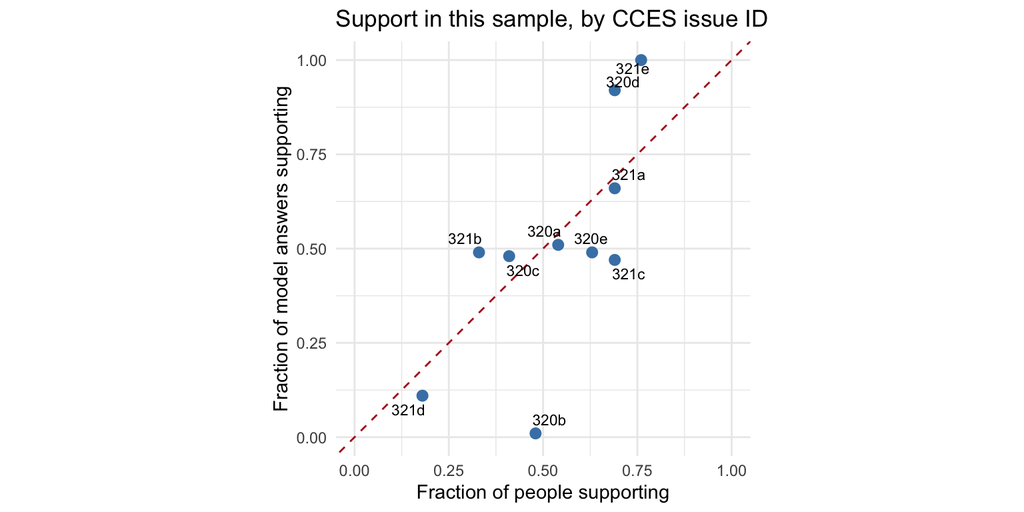

## Reading the plot

Above the line, the model’s support fraction is higher; below it, lower. See `issues` for each ID’s exact question. These sample fractions don’t estimate national opinion. Share error and individual accuracy are different quantities.

▸ 13b workbook: run `lab13b-share-plot` for this plot. Next: *Compare simple guesses*

## Compare simple guesses

Use the same 1,000 paired answers: 322 model errors. If we guess each issue’s most common human answer, there are 340 errors. If we guess each party’s most common answer on each issue, there are 303.

▸ 13b workbook: run `lab13b-baselines`

## Why those baselines aren’t held out

Both majorities were calculated from these same people, including the answer being guessed. They’re descriptive, in-sample benchmarks, not prospective performance. Hold out cases to evaluate a baseline fairly.

Stay on slides through *Back to the limits*

## Back to the limits

This example checks one model for one use. It doesn’t establish national representativeness or validate other uses.

Next: ▸ 13b workbook: **Lab**

# Lab

## Lab: a different issue

*~14 minutes.* In `13b-workbook.qmd`, compare one answer, inspect another issue’s support, and explain what the archive can’t tell us. Render, commit, and push.

▸ 13b workbook: **Lab**, Tasks 1–3, then **Finalize 13b**. Then back to slides: *Same habits, your paper*

# Your paper

## Same habits, your paper

What you practiced in 13a:

- **Ask for the judgment calls.** They’re yours to make.
- **Read before you approve.** The plan, the `/diff`, the files in the commit.
- **Check it yourself.** One number, computed your own way.

Soon Amanda and I will download your repository and try to render your paper. I’ll announce the date.

This slide and the next, then ▸ 13a workbook: **Your paper**

## `PAPER.md`: tell Codex about your paper once

`PAPER.md` is a template at the top of your repository. `AGENTS.md` tells Codex to read it before working on your paper. It’s the paper’s version of the sandbox’s `AGENTS.md`.

It has places for:

- **The question**, and **the data**: where they came from, where they are.
- **Where things are:** the main file, the bibliography, the code.
- **How to render** the paper.
- **Where it stands**, and rules for working on it.

You don’t fill it in by hand. Codex interviews you, one question at a time, and writes it. You read the `/diff` and correct anything wrong or invented.

Then ▸ 13a workbook: **Your paper**

## Your paper, for about 15 minutes

At your own pace, from `13a-workbook.qmd`, at **Your paper**. Every prompt is there. Amanda and I come around.

Start: type `/exit`, then `course` and `codex`, so Codex sees your whole repository.

1. **`PAPER.md`.** Codex interviews you and fills in the template: your question, your data, your main file.
2. **Fix one thing.** Something broken or missing, like a README.
3. Repeat 2 as time allows.

What you don’t finish, you finish on your own before the paper check.

▸ 13a workbook: **Your paper**

## Fix one thing

1. Say what’s wrong in a sentence or two, and ask Codex for the judgment calls before it plans.
2. Read the plan, then approve.
3. Type `/diff`. Only the files in the plan should change.
4. Check it yourself: run it, or recompute one number.
5. Add three lines to `NOTES.md` in your paper folder: what you asked, what you checked, what Codex got wrong.
6. Have Codex commit and push.

▸ 13a workbook: **Your paper** › Fix one thing

## A good `NOTES.md` entry

```markdown
## November 18

- Asked Codex to read the survey from Paper/Data instead of my
  Downloads folder.
- Checked: the row count matched the raw file (1,204), and the
  paper still rendered.
- Codex also renamed a variable I hadn't asked about. I undid that.
```

Three lines: what you asked, what you checked, what it got wrong. They’re one of the four things the paper check looks for, and the start of the AI-use statement your final paper needs.

▸ 13a workbook: **Your paper** › Fix one thing

## No paper ready? Use the fallback

A small task with a known answer. `Labs/w13/fallback/model-labels.csv` holds a person’s label and a model’s label for 20 short comments. Type `/exit`, then:

```bash
course
z Labs/w13
codex
```

```
The CSV in fallback/ has a human label and a model label for 20
short comments. Write fallback/score.R to work out how often the
model agrees with the human. I'll run it from this folder with
source("fallback/score.R"), so it should read
fallback/model-labels.csv. Ask me what's unclear first. Just write
it; I'll run it.
```

Same habits from there. The workbook has the checks.

▸ 13a workbook: **If your paper isn’t ready**

# Wrapping up

## Problem Set 7

Released today; due **Thursday, December 3 at 10 AM**. Make a small eval with 10–20 labeled cases, compare GPT-5.6 Luna and Terra on the same held-out cases, and write a mini leaderboard and memo. AI is required. A synthetic fallback is supplied.

Stay on slides through *Before Next Class*

## Before Next Class

- Save, render, inspect, commit, push, and confirm both workbooks, 13a and 13b, on GitHub. If rendering fails, record the error and still push the saved QMD.
- **Before the paper check:** make sure your paper folder has a README and `NOTES.md`. `Labs/w13/repo-check-checklist.md` has the full list.
- Finish incomplete lab work by 7:00 PM the night before our next class.
- Next class: text annotation and validation. Begin Set 7 early enough to check access and save outputs.

If time remains: ▸ 13b workbook: **If Time Remains**

# If Time Remains

## Extension 1: an error’s explanation

*~8 minutes.* Find an incorrect archived answer, read the explanation, and consider what it can and cannot tell us about the person.

▸ 13b workbook: **Extension 1**

## Extension 2: another subgroup

*~10 minutes.* Compare sample support fractions for another issue and one party. Report the number of people and explain why a small subgroup may be unstable.

▸ 13b workbook: **Extension 2**

## Extension 2: subgroup counts

Compare the fractions only after checking `n`. The 100 people are an unweighted subset; small groups can be especially sensitive to individual answers. This doesn’t prove a general law about rare profiles.

▸ 13b workbook: **Extension 2**

## Extension 2: compare issue shares

The same party can look different on different policies. Choose an issue from `issues`, then use the workbook’s provided subgroup calculation; don’t generalize from a single cell.

▸ 13b workbook: **Extension 2**

## Extension 2: a cached polarization comparison

The book jointly estimated a one-dimensional scale from the stacked human and model responses to these ten questions. This is a model-based summary of this small sample, not a population estimate.

```r
set.seed(6394)
ideal_points |> slice_sample(n = 10) |> select(source, party, ideal_point)
```

```
# A tibble: 10 × 3
   source party       ideal_point
   <chr>  <chr>             <dbl>
 1 llm    Republican        0.610
 2 human  Independent       0.113
 3 llm    Republican        0.590
 4 llm    Democrat         -1.11
 5 human  Republican        0.355
 6 human  Independent       1.71
 7 llm    Democrat         -1.19
 8 human  Republican        0.844
 9 llm    Independent      -0.563
10 human  Democrat         -0.385
```

▸ 13b workbook: **Extension 2**

## Extension 2: compare median gaps

```r
ideal_points |> filter(party %in% c("Democrat", "Republican")) |>
  group_by(source, party) |> summarize(median_score = median(ideal_point)) |>
  pivot_wider(names_from = party, values_from = median_score) |>
  mutate(gap = Republican - Democrat)
```

```
# A tibble: 2 × 4
# Groups:   source [2]
  source Democrat Republican   gap
  <chr>     <dbl>      <dbl> <dbl>
1 human    -0.215      0.406 0.621
2 llm      -1.33       1.08  2.42
```

The cached model gap is larger here. Changing questions, sample, or scaling model may change the comparison.

▸ 13b workbook: **Extension 2**

## Extension 3: what is a decision model?

A decision system takes evidence and a question and returns a typed result, such as a choice among fixed labels. The options make the output usable in code; they don’t make it correct.

▸ 13b workbook: **Extension 3: structured decisions**

## Extension 3: three ways to get a decision

A general model can return structured output; specialized models such as Clef offer decision interfaces; OpenAI Decisions provides an endpoint using `gpt-6-luna`. Similar outputs don’t imply identical architectures or measure the same thing.

▸ 13b workbook: **Extension 3: structured decisions**

## Extension 3: a choice request

Shared input is evidence; the question specifies the choices. This is a **synthetic illustration**, not an observed API result.

```json
{
  "input": "It is 2021. You are 54, female, and Republican.",
  "question": "Support or oppose expanding Medicare to cover all Americans?",
  "choices": ["Support", "Oppose"]
}
```

▸ 13b workbook: **Extension 3: structured decisions**

## Extension 3: a choice response

Illustrative shape, invented numbers:

```json
{
  "choice": "Support",
  "probabilities": [
    {"value": "Support", "probability": 0.8},
    {"value": "Oppose", "probability": 0.2}
  ]
}
```

These numbers aren’t automatically calibrated probabilities, truth, or fractions of humans.

▸ 13b workbook: **Extension 3: structured decisions**

## Extension 3: parse the synthetic example

`jsonlite::fromJSON()` reads the supplied file; `simplifyVector = FALSE` keeps nested arrays as lists. `[[1]]` selects the first answer.

```r
example <- jsonlite::fromJSON("Demos/decision-example.json", simplifyVector = FALSE)
example$answers[[1]]$choice
```

```
[1] "Support"
```

▸ 13b workbook: **Extension 3: structured decisions**

## Extension 3: how to check a probability

Collect independently labeled cases. Among cases assigned Support probability near 0.8, compare the fraction actually labeled Support to 0.8. One answer cannot establish calibration.

▸ 13b workbook: **Extension 3: structured decisions**

## Extension 3: the actual endpoint

The supplied `Demos/decisions.R` uses `httr2` to POST to `/v1/decisions`, then `jsonlite::fromJSON(..., simplifyVector = FALSE)` to parse the body. The bearer key comes from the environment, not the URL. `ellmer` structured chat uses Responses; it isn’t Decisions.

▸ 13b workbook: **Extension 3: structured decisions**

## Extension 3: a runnable call, if available

We reuse `persona(7)` and the first survey question, Medicare expansion (`320a`). `source()` loads the helper; each `list()` gives an option’s value and meaning. Optional live call; leave it disabled when rendering.

```r
source("Demos/decisions.R")
result <- decide_choice(persona(7), issues$question[1],
  list(list(value = "Support", description = "Supports the proposal"),
       list(value = "Oppose", description = "Opposes the proposal")))
result$answers
```

▸ 13b workbook: **Extension 3: structured decisions**

## Extension 3: other systems

Cloudflare’s Clef has downloadable weights. Boris calls Jev (`typesafe/jev-1.13`) and Clef (`cloudflare/clef`) through OpenRouter’s Decisions endpoint. OpenAI Decisions uses `gpt-6-luna`; Set 7 keeps GPT-5.6 Luna/Terra. We’ll read Boris’s saved results.

Jev reappears December 1 for topic classification (15a).

▸ 13b workbook: **Extension 3: structured decisions**

## Extension 3: one person, three systems

*~2 minutes.* Person 7, Medicare expansion (`320a`). The helper reads Boris’s saved calls for four pairs on three systems; it makes no request.

```r
source("Demos/silicon-comparison.R")
decision_comparison <- read_silicon_comparison(combined_results)
silicon_comparison_table(decision_comparison) |>
  knitr::kable(digits = 3, caption = "Person 7, issue 320a. Boris's cached calls.")
```

Person 7, issue 320a. Boris’s cached calls.

| Source | Answer | Chat confidence | P(Support) | P(Oppose) |
| --- | --- | --- | --- | --- |
| Archive chat | Oppose | High | NA | NA |
| OpenAI Decisions | Oppose | NA | 0.07 | 0.93 |
| Jev | Oppose | NA | 0.00 | 1.00 |
| Clef | Oppose | NA | 0.02 | 0.98 |
| Recorded answer | Oppose | NA | NA | NA |

Archive: GPT-5.4 Mini, fuller persona. All three decision systems use today’s short persona. Compare OpenAI’s uncertainty with Jev and Clef’s near-certainty.

## Extension 3: where the models disagree

Support probabilities from the saved calls. Every recorded answer in these four cases was Oppose.

| person | issue | OpenAI Decisions | Jev | Clef |
| --- | --- | --- | --- | --- |
| 7 | 320a | 0.07 | 0.00 | 0.02 |
| 8 | 320a | 0.34 | 0.01 | 0.02 |
| 9 | 320b | 0.31 | 0.06 | 0.10 |
| 10 | 320c | 0.62 | 0.09 | 0.20 |

On person 10/`320c`, OpenAI chooses Support; Jev and Clef choose Oppose. OpenAI matches 3 of these 4 answers; Jev and Clef match 4. Four single calls aren’t response rates or evidence of calibration.

▸ 13b workbook: **Extension 3: structured decisions**

## Sources

- CCES data, archived GPT-5.4 Mini run, and the limits from *Large Language Models for Public Opinion Research*, chapter 2.
- Verasight, *Synthetic Sampling Report VI*: 2026 Senate races (November 2026).
- Argyle et al., “Out of One, Many,” *Political Analysis* (2023); Bisbee et al., “Synthetic Replacements for Human Survey Data?” *Political Analysis* (2023).
- [OpenAI Decisions](https://developers.openai.com/api/docs/guides/decisions); [ellmer OpenAI](https://ellmer.tidyverse.org/reference/chat_openai.html).
- [Cloudflare Clef](https://developers.cloudflare.com/changelog/post/2026-10-01-clef-workers-ai/); [OpenRouter Decisions](https://openrouter.ai/docs/api/api-reference/alphadecisions/submit-a-decisions-request).